# 305-2017-11-02-example-after-basic_and_optimized_lu_fn

/Volumes/lacie/aaa/packages/gatars/gails-stuff/02-examples-for-website-data

Last knit was 2017-11-02 15:57:29

# 1 A little history for the 305 file

The data set in `gatars`: `gatars_example` I will be creating here.

There is some history. From `lacie/aaa/packages/gritsr2/gails-stuff/a-chronicle/04-v-0.1.4.html` I see that gritsr2 contains the following four data sets

```
bim_original.RData
exclusion_region.RData
genotype_bim_original.RData
hotspot.RData
```

`bim_original` is a data.frame containing the columns `chromosome`, `snp`, and `bp` and 124303 rows, so these are possibilities for sampling sets.

`genotype_bim_original` is a data.frame containing the columns `chromosome`, `snp`, and `bp` and 47 rows, so these are possibilities for target markers.

`hotspot` is a data.frame with 25657 rows and the columns `chromosome`, `center`, `start` and `end`.

which I moved from `d-2016-04-20/06-adding-valeries-data/gritsr_packages_RData`

These files were created by “107-2016-10-24-description-adding-valeries-data.Rmd”

The code below, I copied from “lacie/aaa/packages/gritsr2/gails-stuff/b-examples/03-v-0.1.4/a-build-hg38/201-gritsr-example-dot-RData”

```r
library(gatars)
library(gritsr2)
set.seed(31)
RData_file = "gatars_example.RData"
source_0 = getwd()
source_1 = strsplit(source_0, "/")[[1]]
source = paste0(paste(source_1[(length(source_1) - 2):length(source_1)], collapse = "/"),
      "/305-2017-11-02-example-after-basic_and_optimized_lu_fn.Rmd")
genotype_bim_original = genotype_bim_original[1:5, ]
params_example = params_example_fn(
  bim_original, genotype_bim_original, hotspot,
  NNN = 200,
  p_subset_genotype = .2,
  beta_causal_snps = .85,
  causal_snps = 3:5)
gatars_example = example_fn(params_example)
names(gatars_example)
```

```
## [1] "bim"              "genotype"         "exclusion_region"
## [4] "fam"              "target_markers"   "Psi"
```

```r
str(gatars_example$bim)
```

```
## 'data.frame':    24368 obs. of  3 variables:
##  $ chromosome: int  1 1 1 1 1 1 1 1 1 1 ...
##  $ snp       : chr  "exm2216283" "exm2216284" "exm2216292" "exm53" ...
##  $ bp        : int  564766 564862 565111 865665 866429 871159 871276 874501 881918 883947 ...
```

```r
str(gatars_example$genotype)
```

```
##  int [1:200, 1:24368] 0 0 1 1 0 0 1 0 0 0 ...
##  - attr(*, "dimnames")=List of 2
##   ..$ : chr [1:200] "1" "2" "3" "4" ...
##   ..$ : chr [1:24368] "exm2216283" "exm2216284" "exm2216292" "exm53" ...
```

```r
str(gatars_example$exclusion_region)
```

```
## 'data.frame':    115 obs. of  3 variables:
##  $ chromosome: num  1 1 1 1 1 2 2 2 2 2 ...
##  $ start     : int  10496040 150685811 154861707 204549714 205788696 9977740 10570604 20688505 43326810 62904596 ...
##  $ end       : int  10496040 150685811 154861707 204549714 205788696 9977740 10570604 20688505 43326810 62904596 ...
```

```r
str(gatars_example$fam)
```

```
## 'data.frame':    200 obs. of  3 variables:
##  $ id : int  1 2 3 4 5 6 7 8 9 10 ...
##  $ y  : int  1 1 0 1 1 1 1 1 1 1 ...
##  $ e_y: num  0.801 0.819 0.823 0.814 0.801 ...
```

```r
gatars_example$target_markers
```

```
## [1] "exm1061808" "exm1061809" "exm1061853" "exm1061861" "exm1061863"
```

```r
str(gatars_example$Psi)
```

```
##  num [1:200, 1:200] 1 0.5 0 0 0 0 0 0 0 0 ...
```

```r
gatars_example$Psi[1:10, 1:10]
```

```
##       [,1] [,2] [,3] [,4] [,5] [,6] [,7] [,8] [,9] [,10]
##  [1,]  1.0  0.5  0.0  0.0  0.0  0.0  0.0  0.0  0.0   0.0
##  [2,]  0.5  1.0  0.0  0.0  0.0  0.0  0.0  0.0  0.0   0.0
##  [3,]  0.0  0.0  1.0  0.5  0.0  0.0  0.0  0.0  0.0   0.0
##  [4,]  0.0  0.0  0.5  1.0  0.0  0.0  0.0  0.0  0.0   0.0
##  [5,]  0.0  0.0  0.0  0.0  1.0  0.5  0.0  0.0  0.0   0.0
##  [6,]  0.0  0.0  0.0  0.0  0.5  1.0  0.0  0.0  0.0   0.0
##  [7,]  0.0  0.0  0.0  0.0  0.0  0.0  1.0  0.5  0.0   0.0
##  [8,]  0.0  0.0  0.0  0.0  0.0  0.0  0.5  1.0  0.0   0.0
##  [9,]  0.0  0.0  0.0  0.0  0.0  0.0  0.0  0.0  1.0   0.5
## [10,]  0.0  0.0  0.0  0.0  0.0  0.0  0.0  0.0  0.5   1.0
```

```r
gatars_example$params_example = params_example

additional_attributes = list(
  RData_file = RData_file,
  when_created = Sys.time(),
  source = source
)
attributes(gatars_example) = c(attributes(gatars_example),
                                    additional_attributes)

save(gatars_example, file = RData_file)
```

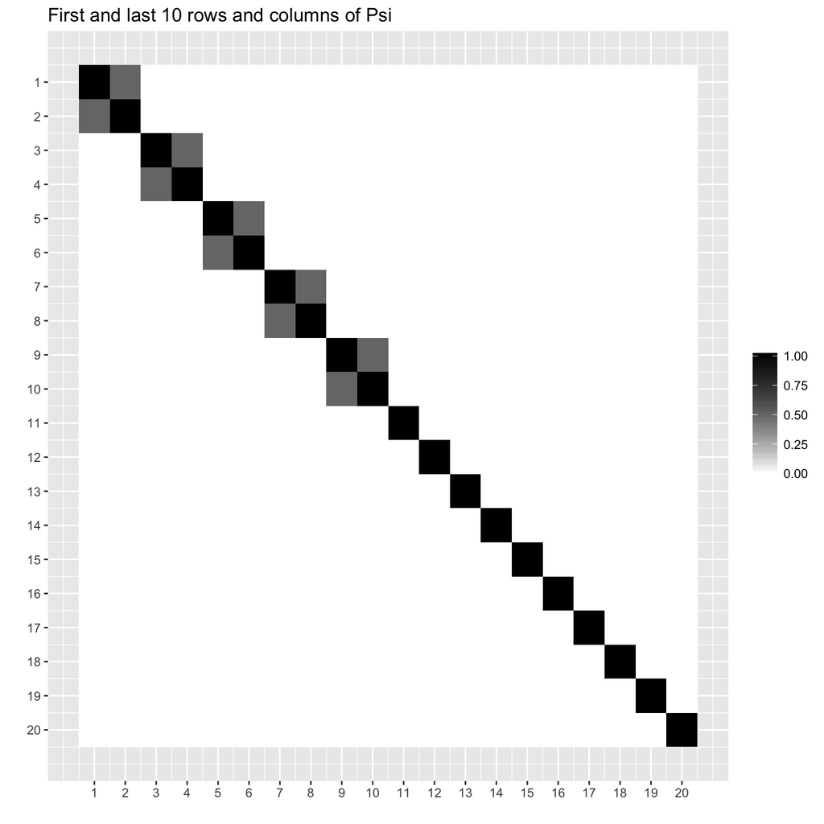

```r
# here i am calling `gatars`
bim = gatars_example$bim
exclusion_region = gatars_example$exclusion_region
fam = gatars_example$fam
genotype = gatars_example$genotype
target_markers = gatars_example$target_markers[3:5]
Psi = gatars_example$Psi
NNN = nrow(fam)
first_ten = 1:10
last_ten = NNN - (9:0)
matrix_image_fn(Psi[c(first_ten, last_ten), c(first_ten, last_ten)],
                main = "First and last 10 rows and columns of Psi")
```

```r
# Checking the rank of the genotype_target_markers matrix
library(Matrix)
genotype_target_markers = genotype[, target_markers]
list(target_markers = target_markers,
     rank = as.numeric(rankMatrix( genotype_target_markers)))
```

```
## $target_markers
## [1] "exm1061853" "exm1061861" "exm1061863"
##
## $rank
## [1] 3
```

```r
# Creating the sampling_set
set.seed(1)
epsilon_on_log_scale = 0.01
exclusion_region = NULL
sampling_set = gatars_sampling_set(
  bim,
  epsilon_on_log_scale,
  exclusion_region,
  genotype,
  hotspot,
  target_markers
)
print(sampling_set)
```

```
## $sampling_set_report
##      min p_target    max set_size
## 1 0.0875   0.0875 0.0875      432
## 2 0.0225   0.0225 0.0225      622
## 3 0.1150   0.1150 0.1150      101
##
## $minimum_sampling_set_size
## [1] 101
```

```r
previous_sampling_set = sampling_set
set.seed(1)
exclusion_region = gatars_example$exclusion_region
head(exclusion_region)
```

```
##    chromosome     start       end
## 1           1  10496040  10496040
## 2           1 150685811 150685811
## 3           1 154861707 154861707
## 4           1 204549714 204549714
## 5           1 205788696 205788696
## 11          2   9977740   9977740
```

```r
sampling_set = gatars_sampling_set(
  bim,
  epsilon_on_log_scale,
  exclusion_region,
  genotype,
  hotspot,
  target_markers
)
print(previous_sampling_set)
```

```
## $sampling_set_report
##      min p_target    max set_size
## 1 0.0875   0.0875 0.0875      432
## 2 0.0225   0.0225 0.0225      622
## 3 0.1150   0.1150 0.1150      101
##
## $minimum_sampling_set_size
## [1] 101
```

```r
print(sampling_set)
```

```
## $sampling_set_report
##      min p_target    max set_size
## 1 0.0875   0.0875 0.0875      353
## 2 0.0225   0.0225 0.0225      501
## 3 0.1150   0.1150 0.1150       84
##
## $minimum_sampling_set_size
## [1] 84
```

```r
# Calling gatars
set.seed(2)
start = Sys.time()
gatars(fam, Psi, sampling_set, N_sim_reps = 100, weights = c(5, 3, 2))
```

```
## $N_sim_reps_required
## [1] 100
##
## $p_value
##           B           S           T          BS          BT          ST
## 0.028538072 0.088630044 0.025692579 0.040000000 0.010000000 0.020000000
##         BST
## 0.020000000
##
## $q
##          B          S          T         BS         BT         ST
##  91.083941  44.173938 553.482902  91.083941 133.402133 553.482902
##        BST
## 133.386374
##
## $x
##        BS        BT        ST       BST
## 1.5445754 1.7885796 1.5901923 1.7885796
```

```r
elapsed_time = Sys.time() - start
elapsed_time
```

```
## Time difference of 22.383682 secs
```

```r
start = Sys.time()
gatars(fam, Psi, sampling_set, N_sim_reps = 1000, weights = c(5, 3, 2))
```

```
## $N_sim_reps_required
## [1] 1000
##
## $p_value
##           B           S           T          BS          BT          ST
## 0.028538072 0.088630044 0.025692579 0.038000000 0.028000000 0.040000000
##         BST
## 0.031000000
##
## $q
##          B          S          T         BS         BT         ST
##  91.083941  44.173938 553.482902  91.083941 133.402133 553.482902
##        BST
## 133.386374
##
## $x
##        BS        BT        ST       BST
## 1.5445754 1.7885796 1.5901923 1.7885796
```

```r
elapsed_time = Sys.time() - start
elapsed_time
```

```
## Time difference of 3.6955112 mins
```

```r
start = Sys.time()
gatars(fam, Psi, sampling_set, N_sim_reps = 2000, weights = c(5, 3, 2))
```

```
## $N_sim_reps_required
## [1] 2000
##
## $p_value
##           B           S           T          BS          BT          ST
## 0.028538072 0.088630044 0.025692579 0.036500000 0.019000000 0.035000000
##         BST
## 0.028000000
##
## $q
##          B          S          T         BS         BT         ST
##  91.083941  44.173938 553.482902  91.083941 133.402133 553.482902
##        BST
## 133.386374
##
## $x
##        BS        BT        ST       BST
## 1.5445754 1.7885796 1.5901923 1.7885796
```

```r
elapsed_time = Sys.time() - start
elapsed_time
```

```
## Time difference of 7.3716887 mins
```